# Week One

## Case Study: Sampling

## Case Study: Sampling

We can estimate the mean \(\mu\) of a population of size \(N\) in two ways:

1. Take a simple random sample of size \(n\) and calculate \(\bar{x}\).
2. Take a stratified sample of \(n_1\) from the first strata and \(n_2\) from the second strata, proportionally, then compute \(\bar{x}\).

Which estimate (r.v.) will have lower **bias**? Lower **variance**?

## Set up population

```r
set.seed(403)
```

```r
# generate population
N_1 <- 200
N_2 <- 300
g1 <- rnorm(N_1, mean = 1, sd = 1)
g2 <- rnorm(N_2, mean = 3, sd = 1)
pop <- c(g1, g2)
```

```r
# lay out parameters
N <- N_1 + N_2
l_1 <- N_1/N
l_2 <- N_2/N
mu_1 <- mean(g1)
sigsq_1 <- var(g1) * (N_1 - 1) / N_1
mu_2 <- mean(g2)
sigsq_2 <- var(g2) * (N_2 - 1) / N_2
```

## One simple random sample

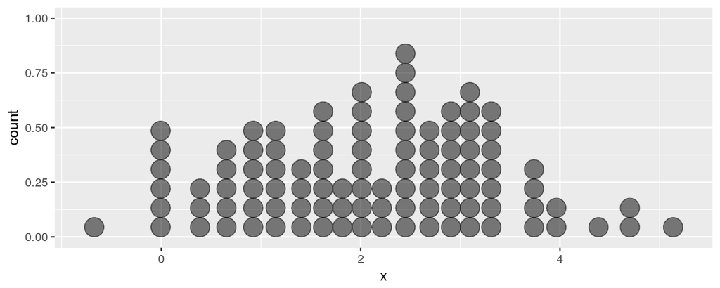

```r
n <- 100
samp <- sample(pop, size = n)
df <- data.frame(x = samp)
library(tidyverse)
ggplot(df, aes(x = x)) + # dotplot
  geom_dotplot(alpha = .5)
```

## One simple random sample, cont

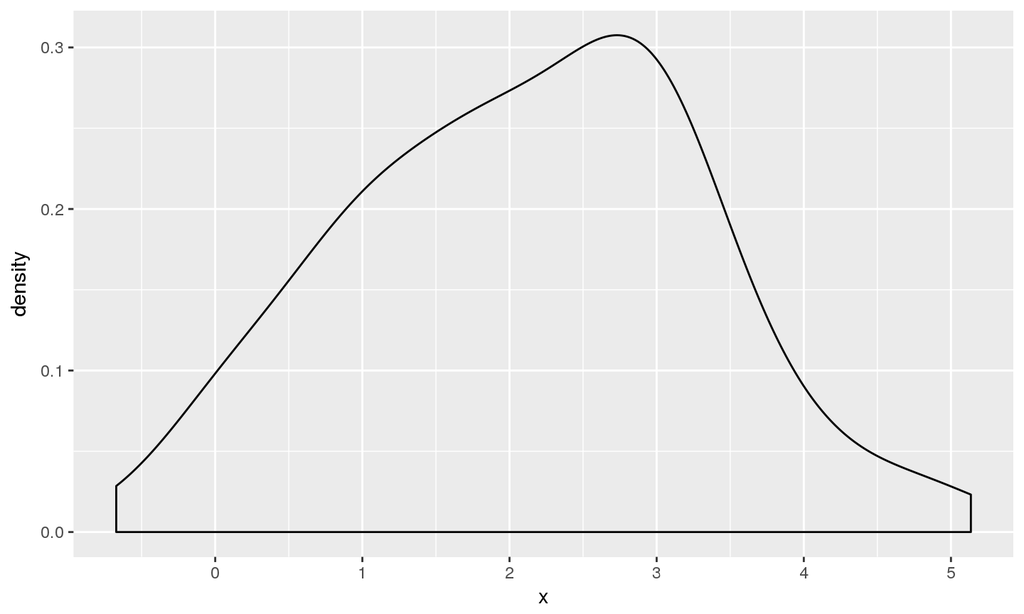

```r
# Density plot
ggplot(df, aes(x = x)) +
  geom_density(alpha = .5)
```

```r
mean(samp)
```

```
## [1] 2.120808
```

## Simulation: simple random sampling

```r
it <- 5000
xbar_srs <- rep(NA, it)
for (i in 1:it) {
  samp <- sample(pop, size = n)
  xbar_srs[i] <- mean(samp)
}
```

```r
head(xbar_srs)
```

```
## [1] 2.259436 2.186173 2.350354 2.413095 2.196920 2.413875
```

## One stratified sample

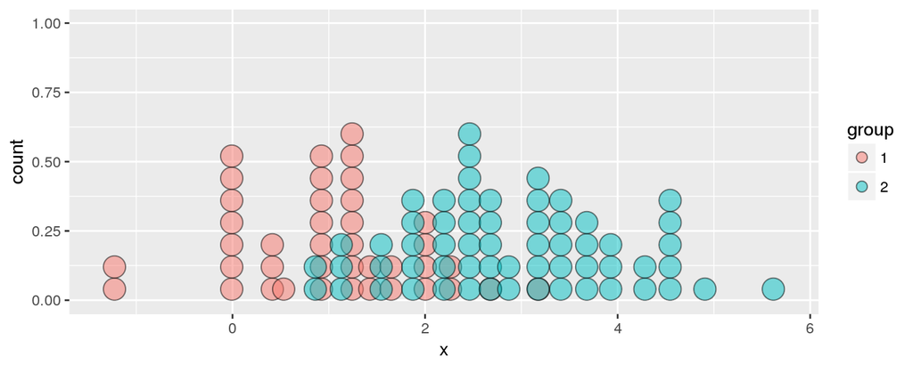

```r
n_1 <- n * l_1
n_2 <- n * l_2
samp_1 <- sample(g1, size = n_1)
samp_2 <- sample(g2, size = n_2)
df <- data.frame(x = c(samp_1, samp_2),
                 group = rep(c("1", "2"), times = c(n_1, n_2)))
ggplot(df, aes(x = x, fill = group)) +
  geom_dotplot(alpha = .5)
```

## One stratified sample, cont.

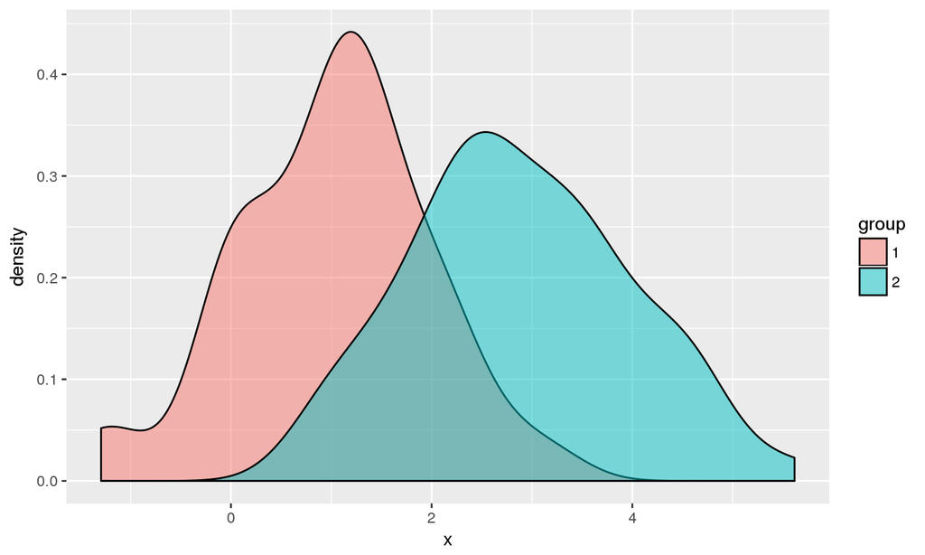

```r
ggplot(df, aes(x = x, fill = group)) +
  geom_density(alpha = .5)
```

## Simulation: stratification

```r
xbar_strat <- rep(NA, it)
for (i in 1:it) {
  samp_1 <- sample(g1, size = n_1)
  samp_2 <- sample(g2, size = n_2)
  xbar_strat[i] <- mean(c(samp_1, samp_2))
}
```

```r
head(xbar_strat)
```

```
## [1] 2.171014 2.079023 2.272035 2.387336 2.210160 2.200704
```

## Simulations compared

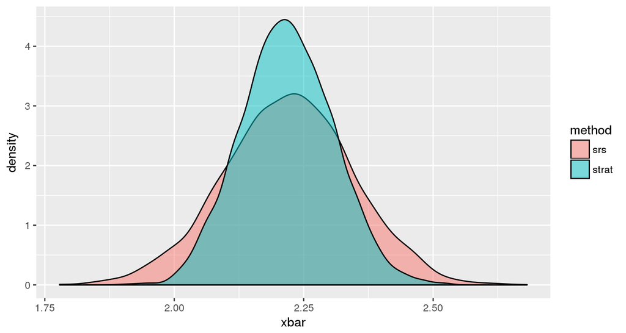

```r
df <- data.frame(xbar = c(xbar_srs, xbar_strat),
                 method = rep(c("srs", "strat"), times = c(it, it)))
ggplot(df, aes(x = xbar, fill = method)) +
  geom_density(alpha = .5)
```

## Simulation vs Analytical

Through simulation, we have an empirical approximation to the variances of each estimate that we can compare to our analytical estimates.

```r
#SRS
var(xbar_srs)
```

```
## [1] 0.01549621
```

```r
(1/n) * (var(pop) * (N-1)/N)
```

```
## [1] 0.01948775
```

```r
# stratified
var(xbar_strat)
```

```
## [1] 0.00785268
```

```r
(1/n) * (l_1 * sigsq_1 + l_2 * sigsq_2)
```

```
## [1] 0.009960774
```

## Simulation vs Analytical, cont.

We can more directly compare the analytical variances by writing the SRS estimate in terms of the strata variances and finding the difference in the variances of the two estimates.

\[ \textrm{difference:} \quad \frac{1}{n} \sum_{j = 1}^J \lambda_j \left( \mu_j - \mu \right)^2 \]

### Simulation-Empirical-Computational Approach

- Helps build intuition
- Checks analytical result
- Widely applicable

### Analytical Approach

- When it is exists, it is:
  - more general
  - often yields insight

## EDA: graphics

## Example: Flight Delays

`FlightDelays` contains informations on flights from LGA during May and June of 2009.

```r
library(resampledata)
glimpse(FlightDelays)
```

```
## Observations: 4,029
## Variables: 10
## $ ID           <int> 1, 2, 3, 4, 5, 6, 7, 8, 9, 10, 11, 12, 13, 14, 15...
## $ Carrier      <fct> UA, UA, UA, UA, UA, UA, UA, UA, UA, UA, UA, UA, U...
## $ FlightNo     <int> 403, 405, 409, 511, 667, 669, 673, 677, 679, 681,...
## $ Destination  <fct> DEN, DEN, DEN, ORD, ORD, ORD, ORD, ORD, ORD, ORD,...
## $ DepartTime   <fct> 4-8am, 8-Noon, 4-8pm, 8-Noon, 4-8am, 4-8am, 8-Noo...
## $ Day          <fct> Fri, Fri, Fri, Fri, Fri, Fri, Fri, Fri, Fri, Fri,...
## $ Month        <fct> May, May, May, May, May, May, May, May, May, May,...
## $ FlightLength <int> 281, 277, 279, 158, 143, 150, 158, 160, 160, 163,...
## $ Delay        <int> -1, 102, 4, -2, -3, 0, -5, 0, 10, 60, 0, 32, 0, 4...
## $ Delayed30    <fct> No, Yes, No, No, No, No, No, No, No, Yes, No, Yes...
```

## United delays: histogram

[figure not shown]

X axis is cut into intervals of equal width, the height of the bars indicate the number of obs in each.

## United delays: normalized histogram

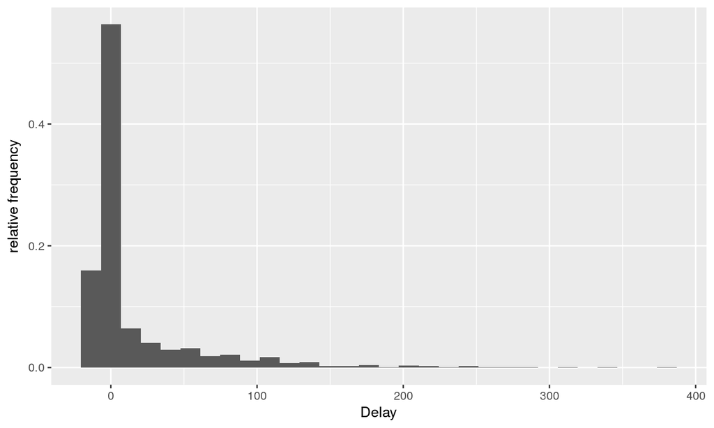

In this case the height of the bars reflect the mass so that the sum of the heights of the bars is 1.

## Density plot as an approx.

Say you take a sample of \(n=1000\) values from a Normal\((0,1)\) random variable with pdf \(f(x) = \frac{1}{\sqrt{2\pi}}\exp\left(-\frac{1}{2}x^2\right)\)

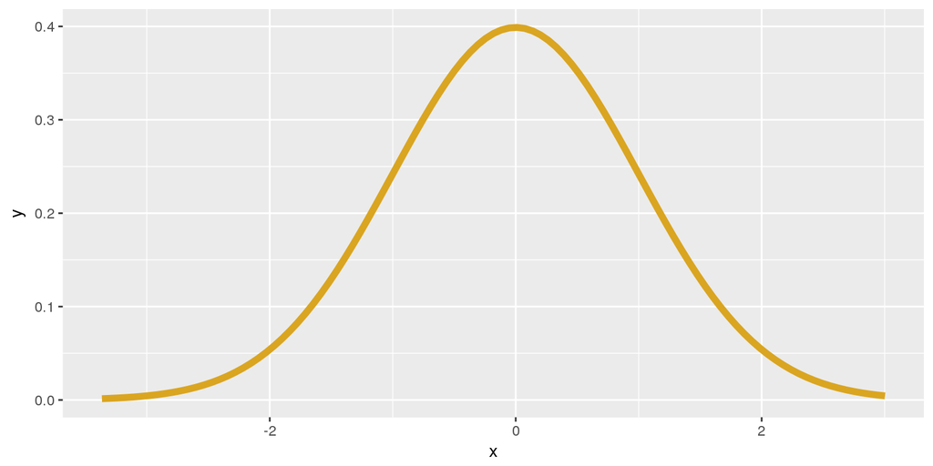

## Density plot as an approx.

The density plot is visual approximation of the pdf \(f(x)\), using a smoothing parameter \(\sigma\).

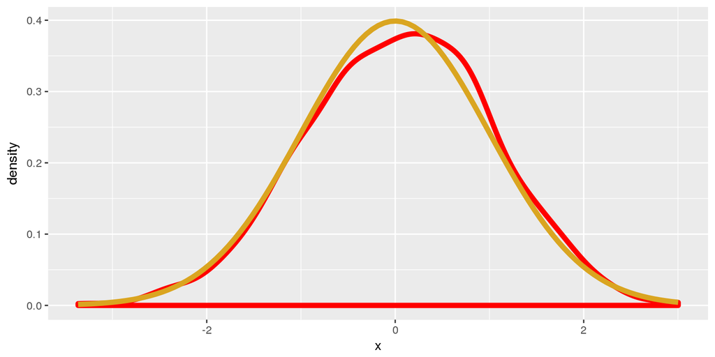

## Density plot as an approx.

Lets visualize just 4 points instead of 1000…

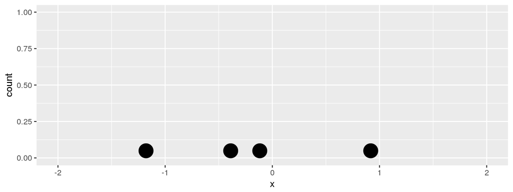

## Density plot as an approx.

and overlay the density plot with \(\sigma = .25\).

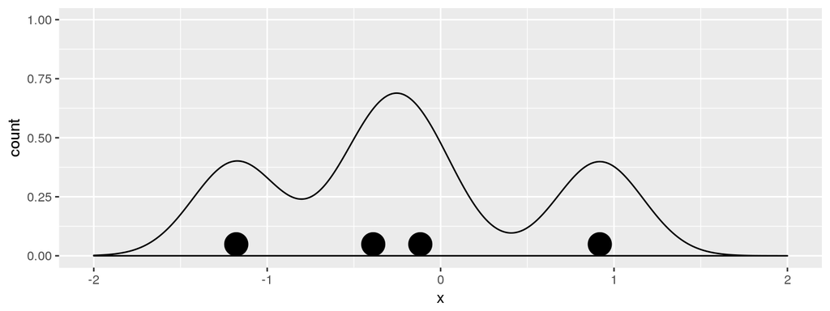

this is a *kernel smoother* where \(\hat{f}(x) = 1/n \sum_{i=1}^n k_i(x)\), where \(k_i\) is the Gaussian pdf with \(\mu = x_i\) and \(\sigma = \sigma\).

## Density plot as an approx.

The higher the \(\sigma\), the smoother the approximation (\(\sigma = 1\))

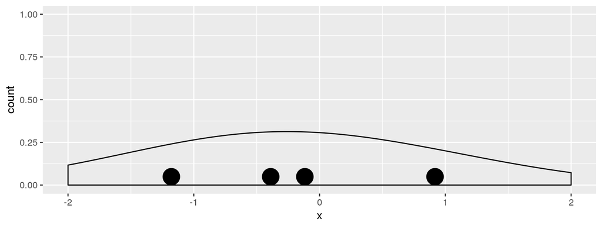

## Boxplots

United Flight Delays from LGA broken down by day of the week.

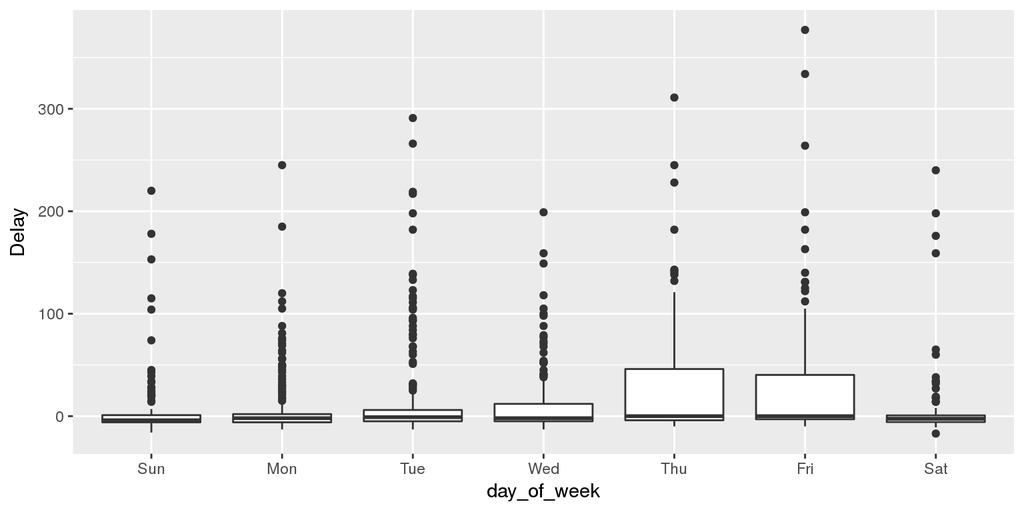

## Boxplots

United Flight Delays from LGA broken down by day of the week.

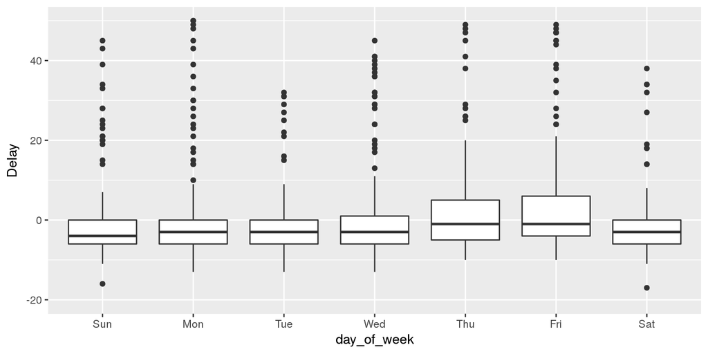

## Boxplots without the Whiskers

What is [middle class](https://www.washingtonpost.com/news/wonk/wp/2015/03/23/middle-class-varies-from-30000-in-detroit-to-100000-in-san-francisco/) in various cities?

## Scatterplot

An approximation of the joint distribution of two variables (with no smoothing).

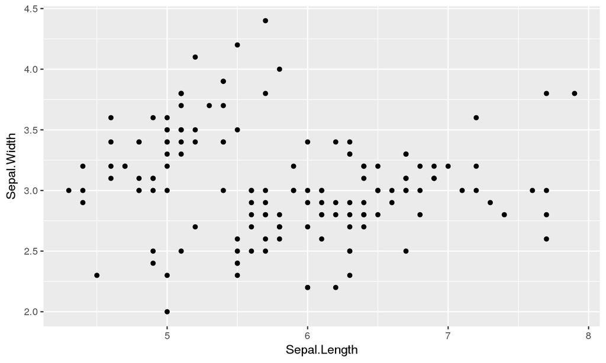

```r
ggplot(iris, aes(x = Sepal.Length, y = Sepal.Width)) +
  geom_point()
```

## Contour plot

An approximation of the joint distribution of two variables (with kernel smoothing).

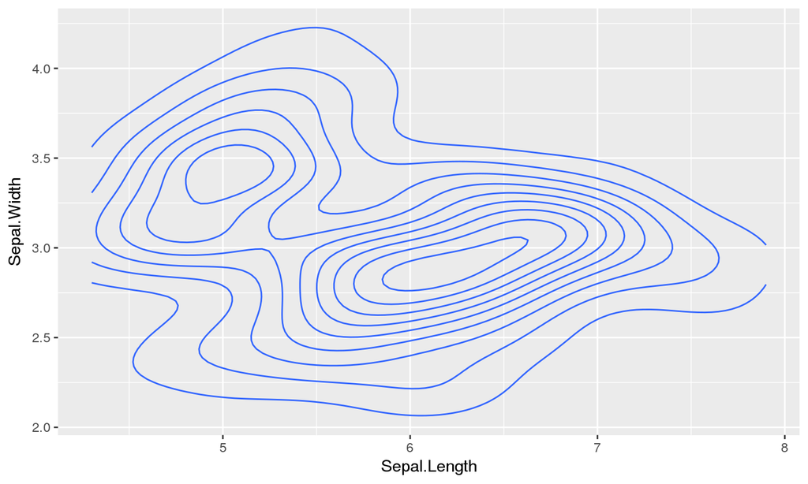

```r
ggplot(iris, aes(x = Sepal.Length, y = Sepal.Width)) +
  geom_density_2d()
```

## EDA: Numerical Summaries

## Robustness

Say at company \(X\), there 5 employees with the following weekly income:

| Salary | CEO | Grunt 1 | Grunt 2 | Grunt 3 | Grunt 4 |
| --- | --- | --- | --- | --- | --- |
| $ | 1000 | 20 | 21 | 30 | 40 |

Then:

- Mean $222.2
- Median $30

A statistic is **robust** if it is insensitive to the presence of outliers (ex: median, trimmed mean, IQR).

## QQ plot

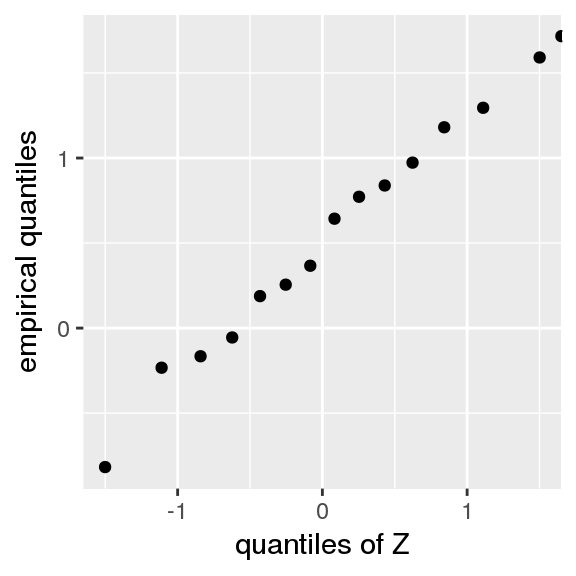

```r
n <- 15
x <- rnorm(n)
df <- data.frame(x = qnorm(1:n/n),
                 y = sort(x))
ggplot(df, aes(x = x, y = y)) +
  geom_point() +
  xlab("quantiles of Z") +
  ylab("empirical quantiles")
```